# Stroop Data Project

## Background Information

In a Stroop task, participants are presented with a list of words, with each word displayed in a color of ink. The participant’s task is to say out loud the color of the ink in which the word is printed. The task has two conditions: a congruent words condition, and an incongruent words condition. In the congruent words condition, the words being displayed are color words whose names match the colors in which they are printed: for example RED , BLUE . In the incongruent words condition, the words displayed are color words whose names do not match the colors in which they are printed: for example PURPLE , ORANGE . In each case, we measure the time it takes to name the ink colors in equally-sized lists. Each participant will go through and record a time from each condition. Questions For Investigation

### 1. What is our independent variable? What is our dependent variable?

**Dependent Variable :** The time taken to read the words  
**Independent Variable :** Congruent and Incongruent words condition

### 2. What is an appropriate set of hypotheses for this task? What kind of statistical test do you expect to perform?

**Null Hypothesis :** There is no difference in the population response time in both congruent(μ<sub>c</sub>) and incongruent conditions(μ<sub>ic</sub>)  
**Alternate Hypothesis:** Incongruent Words condition will increase the reading time (Alternate Hypothesis will be our end goal i.e to see the effect of Incongruent Words condition on reading)

H<sub>0</sub> : μ<sub>c</sub> ≥ μ<sub>ic</sub>  
H<sub>A</sub> : μ<sub>c</sub> < μ<sub>ic</sub>

And we will be doing a t-test statistics because we are comparing two means and also we dont have much information about the population mean or standard deviation. Since we are checking the increase in time between two related tasks it will be a Dependent One tailed positive direction t-test. As our sample size is small t-test will be more suitable.

I will be doing an one-tailed dependent sample t-test, because:

- Population distribution and standard deviation are unknown, and our sample size is less than 30, so z-score will not be appropriate here as it requires details about the population and more sample size. so a test test will be appropriate.
- In this task each tests are identical and paired.
- Based on our sample data we can see that people take more time to read in incongruent condition than in congruent condition. It will be more specific to perform a one-tailed t-test than a two-tailed t-test.

So a one-tailed dependent sample t-test is appropriate here to examine whether the population significantly take more time to read words in incongruent condition than in congruent condition based on our sample.

```python
import pandas as pd
import matplotlib.pyplot as plt
%matplotlib inline
import seaborn as sns
import math
```

```python
stroop_df = pd.read_csv('stroopdata.csv')
```

```python
stroop_df
```

|  | Congruent | Incongruent |
| --- | --- | --- |
| 0 | 12.079 | 19.278 |
| 1 | 16.791 | 18.741 |
| 2 | 9.564 | 21.214 |
| 3 | 8.630 | 15.687 |
| 4 | 14.669 | 22.803 |
| 5 | 12.238 | 20.878 |
| 6 | 14.692 | 24.572 |
| 7 | 8.987 | 17.394 |
| 8 | 9.401 | 20.762 |
| 9 | 14.480 | 26.282 |
| 10 | 22.328 | 24.524 |
| 11 | 15.298 | 18.644 |
| 12 | 15.073 | 17.510 |
| 13 | 16.929 | 20.330 |
| 14 | 18.200 | 35.255 |
| 15 | 12.130 | 22.158 |
| 16 | 18.495 | 25.139 |
| 17 | 10.639 | 20.429 |
| 18 | 11.344 | 17.425 |
| 19 | 12.369 | 34.288 |
| 20 | 12.944 | 23.894 |
| 21 | 14.233 | 17.960 |
| 22 | 19.710 | 22.058 |
| 23 | 16.004 | 21.157 |

### 3. Report some descriptive statistics regarding this dataset. Include at least one measure of central tendency and at least one measure of variability.

```python
print('Central Tendency')
print('Mean Congruent :' + str(stroop_df['Congruent'].mean()))
print('Median Congruent :' + str(stroop_df['Congruent'].median()))
print('Mean Incongruent :' + str(stroop_df['Incongruent'].mean()))
print('Mean Congruent :' + str(stroop_df['Incongruent'].median()))
```

```
Central Tendency
Mean Congruent :14.051125
Median Congruent :14.3565
Mean Incongruent :22.0159166667
Mean Congruent :21.0175
```

```python
print('Variability')
print('Variance Congruent :' + str(stroop_df['Congruent'].var()))
print('Standard Deviation Congruent :' + str(stroop_df['Congruent'].std()))
print('Variance Incongruent :' + str(stroop_df['Incongruent'].var()))
print('Standard Deviation Congruent :' + str(stroop_df['Incongruent'].std()))
```

```
Variability
Variance Congruent :12.6690290707
Standard Deviation Congruent :3.55935795765
Variance Incongruent :23.0117570362
Standard Deviation Congruent :4.79705712247
```

### 4. Provide one or two visualizations that show the distribution of the sample data. Write one or two sentences noting what you observe about the plot or plots.

```
The below plots shows the median & range are different for both Congruent and Incongruent with Incongruent has taken more time
```

[figure not shown]

```python
sns.boxplot(data=stroop_df, palette="PRGn")
print('The below plots shows the median & range are different for both Congruent and Incongruent with Incongruent has taken more time')
```

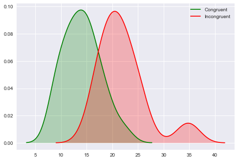

```python
sns.kdeplot(stroop_df['Congruent'], shade=True, color="g")
sns.kdeplot(stroop_df['Incongruent'], shade=True, color="r")
```

### 5. Now, perform the statistical test and report your results. What is your confidence level and your critical statistic value? Do you reject the null hypothesis or fail to reject it? Come to a conclusion in terms of the experiment task. Did the results match up with your expectations?

Type of Test : One Tailed, Positive Direction to see how much the Incongruent Word Condiition is increasing the time

```python
n = 24
print('Number of Samples :' + str(n))
df = n -1
print('Degree of Freedom :' + str(df))
tc = 1.714
print('t Critical (for α = 0.05) :' + str(tc))
stroop_df['diff'] = stroop_df['Incongruent'] - stroop_df['Congruent']
std = stroop_df['diff'].std()
print('Sample Std Deviation :' + str(std))
s_mean = stroop_df['diff'].mean()
print('Sample Mean :' + str(s_mean))
sq_n = math.sqrt(24)
SE = std/sq_n
print('Standard Error of Mean:' + str(SE))
TS = s_mean/SE
print('T Statistic:' + str(TS))
print('p Value < 0.05')
CD = s_mean/std
print('Cohen''s d :' + str(CD))
r2 = (TS * TS) / ((TS * TS) + df)
print('r2 :' + str(r2))
print(str(round(r2*100,2)) + '% of increase in response time is because of this Incongruence Word Condition')
ME = tc * SE
print('Margin of Error :' + str(ME))
CI_L = s_mean - ME
CI_U = s_mean + ME
print('Confidence Interval : (' + str(CI_L) + ',' + str(CI_U)+ ')')
```

```
Number of Samples :24
Degree of Freedom :23
t Critical (for α = 0.05) :1.714
Sample Std Deviation :4.86482691036
Sample Mean :7.96479166667
Standard Error of Mean:0.993028634778
T Statistic:8.02070694411
p Value < 0.05
Cohens d :1.63721994912
r2 :0.736636416145
73.66% of increase in response time is because of this Incongruence Word Condition
Margin of Error :1.70205108001
Confidence Interval : (6.26274058666,9.66684274668)
```

As the T Statistic is greater than T Critical and probability of obtaining the sample mean is less than 0.05, we reject the null hypothesis and conclude that the difference between Congruence and Incongruence Word Condition time difference is statistically significant.

Based on the Confidence Intervals, in future tests the Incongruence Word condition will take 6 to 10 seconds more than the Congruence Word Condition.

### 6. Optional: What do you think is responsible for the effects observed? Can you think of an alternative or similar task that would result in a similar effect? Some research about the problem will be helpful for thinking about these two questions!

As per my understanding it is happening because in the Incongruent Condition the brain has to think parallely at the same time one to get the color and other disregard the Word.

This reminded me of a game we played in college days called 7up, where we need to be in circle and say numbers one by one but when number 7 or number ends with 7 comes you have to say up. So here also you also need to think what number comes next and also keep the seven in mind to say up.